# NMDS on understory vegetation data

Kathleen Stutzman

2024-02-22

Libraries:

```r
# libraries -------------------
library(ggplot2)
library(vegan)
library(ggvegan)
library(tidyverse)
```

Set working directory

```r
knitr::opts_knit$set(root.dir = '/Users/user/Desktop/Data/Regen_RProj/')
```

Functions:

```r
# functions -------------------
```

Import veg script:

```r
source("Scripts/Veg_Data.R")
rm(veg3)
```

Transform veg data for analysis:

```r
#split overall data from veg cover
veg_meta <- veg2 %>%
  select(Region, Treat_Type, Site, Plot_No) %>%
  distinct(Plot_No, .keep_all = TRUE)

#pivot veg data wider and fill in zeros
veg_wider <- veg2 %>%
  select(Plot_No, Species_Code, SP_Cover_midpoint) %>%
  group_by(Plot_No) %>%
  pivot_wider(names_from = Species_Code, values_from = SP_Cover_midpoint, values_fill = 0)

#create dataframe of site and plot
veg_site <- veg2 %>%
  select(Site, Plot_No) %>%
  group_by(Site) %>%
  distinct(Plot_No, .keep_all = TRUE)

# merge site and veg data; remove plot number
merveg <- merge(veg_site, veg_wider, by = "Plot_No") %>%
  select(-Plot_No)
```

At this point, there are 165 species. This is subject to revision, as unknown species are identified

Reduce to species that occur in at least 5% of plots (That is ~25 plots)

```r
#THIS IS 20 plots or more, the last 5 are under 25 plots but above 20
veg_5PERC <- veg_wider %>%
  select(Plot_No,
         QUIL,
         GAPR,
         VAPA,
         CAPE,
         GABA,
         VAAN,
         PTAQ,
         RUSP,
         KAAN,
         PIRI,
         ACRU,
         LYQU,
         QUCO,
         MELI,
         CEOR,
         COPE,
         PRSE,
         QUPR,
         PAQU,
         CEAM,
         QUAL,
         PIST,
         ARME,
         LYBO,
         POUN11,
         RHGL)
# AMSP,
# VAMY,
# FRSP,
# ARNU,
# SMGL)

# check amount of 0s
z6 <- lapply(veg_5PERC, function(x){ length(which(x==0))})
z7 <- as.data.frame(z6)
(sum(z7[,2:27]))/(26*499)
```

```
## [1] 0.7971327
```

```r
rm(z6, z7)
```

Average & relativize the 5% data

```r
# add site and lose plot number -------------------
veg5 <- merge(veg_5PERC, veg_site) %>%
  select(-Plot_No) %>%
  select(Site, everything())

veg5_avg <- veg5 %>%
  group_by(Site) %>%
  summarise_at(vars(QUIL:RHGL), mean) %>%
  column_to_rownames(var = "Site")

rm(veg5, veg_5PERC)

veg5_colsum <- as.data.frame(colSums(veg5_avg))
# CEOR is bittersweet and is only found in APB
# CEAM also an APB only, RHGL maybe too ...

# relativize data, dividing each cell by the column total (to bring common and rare species closer together) -------------------
rel_veg5 <- decostand(veg5_avg, method = 'total', MARGIN = 2)

summary(rel_veg5)
```

```
##       QUIL               GAPR              VAPA              CAPE
##  Min.   :0.000000   Min.   :0.00000   Min.   :0.00000   Min.   :0.000000
##  1st Qu.:0.005694   1st Qu.:0.00000   1st Qu.:0.00000   1st Qu.:0.001501
##  Median :0.014383   Median :0.01256   Median :0.01528   Median :0.008868
##  Mean   :0.021277   Mean   :0.02128   Mean   :0.02128   Mean   :0.021277
##  3rd Qu.:0.033656   3rd Qu.:0.03280   3rd Qu.:0.04079   3rd Qu.:0.039932
##  Max.   :0.089201   Max.   :0.12335   Max.   :0.07206   Max.   :0.112363
##       GABA                VAAN               PTAQ               RUSP
##  Min.   :0.000e+00   Min.   :0.000000   Min.   :0.000000   Min.   :0.0000000
##  1st Qu.:6.952e-05   1st Qu.:0.000000   1st Qu.:0.001096   1st Qu.:0.0000000
##  Median :6.952e-03   Median :0.005758   Median :0.008773   Median :0.0005978
##  Mean   :2.128e-02   Mean   :0.021277   Mean   :0.021277   Mean   :0.0212766
##  3rd Qu.:3.798e-02   3rd Qu.:0.027888   3rd Qu.:0.033668   3rd Qu.:0.0123905
##  Max.   :1.118e-01   Max.   :0.131638   Max.   :0.088743   Max.   :0.2307458
##       KAAN              PIRI               ACRU              LYQU
##  Min.   :0.00000   Min.   :0.000000   Min.   :0.00000   Min.   :0.00000
##  1st Qu.:0.00000   1st Qu.:0.000000   1st Qu.:0.00000   1st Qu.:0.00000
##  Median :0.00000   Median :0.003818   Median :0.00000   Median :0.00000
##  Mean   :0.02128   Mean   :0.021277   Mean   :0.02128   Mean   :0.02128
##  3rd Qu.:0.02483   3rd Qu.:0.019682   3rd Qu.:0.01728   3rd Qu.:0.02026
##  Max.   :0.27636   Max.   :0.187450   Max.   :0.21380   Max.   :0.17555
##       QUCO              MELI              CEOR              COPE
##  Min.   :0.00000   Min.   :0.00000   Min.   :0.00000   Min.   :0.000000
##  1st Qu.:0.00000   1st Qu.:0.00000   1st Qu.:0.00000   1st Qu.:0.000000
##  Median :0.00000   Median :0.00957   Median :0.00000   Median :0.000000
##  Mean   :0.02128   Mean   :0.02128   Mean   :0.02128   Mean   :0.021277
##  3rd Qu.:0.01929   3rd Qu.:0.02010   3rd Qu.:0.00000   3rd Qu.:0.008598
##  Max.   :0.21431   Max.   :0.16668   Max.   :0.43618   Max.   :0.280043
##       PRSE              QUPR               PAQU              CEAM
##  Min.   :0.00000   Min.   :0.000000   Min.   :0.00000   Min.   :0.00000
##  1st Qu.:0.00000   1st Qu.:0.000000   1st Qu.:0.00000   1st Qu.:0.00000
##  Median :0.00000   Median :0.000000   Median :0.00000   Median :0.00000
##  Mean   :0.02128   Mean   :0.021277   Mean   :0.02128   Mean   :0.02128
##  3rd Qu.:0.01547   3rd Qu.:0.004374   3rd Qu.:0.00000   3rd Qu.:0.00000
##  Max.   :0.38042   Max.   :0.254063   Max.   :0.42533   Max.   :0.32878
##       QUAL               PIST              ARME              LYBO
##  Min.   :0.000000   Min.   :0.00000   Min.   :0.00000   Min.   :0.000000
##  1st Qu.:0.000000   1st Qu.:0.00000   1st Qu.:0.00000   1st Qu.:0.000000
##  Median :0.000000   Median :0.00000   Median :0.00000   Median :0.000000
##  Mean   :0.021277   Mean   :0.02128   Mean   :0.02128   Mean   :0.021277
##  3rd Qu.:0.001008   3rd Qu.:0.00000   3rd Qu.:0.01421   3rd Qu.:0.004942
##  Max.   :0.287893   Max.   :0.56875   Max.   :0.22989   Max.   :0.190249
##      POUN11             RHGL
##  Min.   :0.00000   Min.   :0.00000
##  1st Qu.:0.00000   1st Qu.:0.00000
##  Median :0.00000   Median :0.00000
##  Mean   :0.02128   Mean   :0.02128
##  3rd Qu.:0.00000   3rd Qu.:0.00000
##  Max.   :0.42920   Max.   :0.35616
```

I have imported the data; pared the data down to species that occur in at least 5% of plots (aka 25 plots); averaged the data by site; relativized the data by column total. I will be using city-block distances (i.e., Bray-Curtis). Not going to transform the data further at this point

Source & transform other files

```r
time_since <- read_csv("CleanData/Treat_Year_Data.csv") # this is a dataframe with one row for each site
```

```r
# make sure ggpubs not on, or this won't load
source("Scripts/Add_BA.R") #work on prism_BA, has total BA figures - do I need to change these as they were collected on a different scale?
prism1 <- prism_BA %>%
  select(Plot_No, BA_HA, PIRI.BA_HA)

prism2 <- merge(prism1, veg_site, by = "Plot_No") %>%
  select(-Plot_No) %>%
  select(Site, everything())

prism4veg <- prism2 %>%
  group_by(Site) %>%
  summarise_at(vars(BA_HA:PIRI.BA_HA), mean)

rm(prism_BA, prism1, prism2)


source("Scripts/Ground_Data.R") #work on ground 3

ground4 <- ground3 %>%
  select(Plot_No, Lichen, Moss, Rock, Mineral_Soil, Wood, Litter_Duff, avgLD)

ground5 <- merge(ground4, veg_site, by = "Plot_No") %>%
  select(Site, everything()) %>%
  select(-c(Plot_No))

ground4veg <- ground5 %>%
  group_by(Site) %>%
  summarise_at(vars(Lichen:avgLD), mean)

rm(ground3, ground4, ground)
```

Merge envr data to create a envr data matrix for future use in analysis

```r
vegmeta2 <- veg_meta %>%
  select(Region, Treat_Type, Site) %>%
  distinct(Site, .keep_all = TRUE)

vm1 <- merge(vegmeta2, time_since, by = "Site")

vm2 <- merge(vm1, ground4veg, by = "Site")

meta.data_veg <- merge(vm2, prism4veg, by = "Site") %>%
  select(-c(Inventory_Yr, Treat_Yr))


rm(vm2, vm1, time_since, ground4veg, prism4veg)
```

### Run NMDS - start with 6 dimensions and reduce down to 2

```r
#starting with 6 dimensions
test_6d <- metaMDS(rel_veg5,
                   distance = 'bray',
                   k = 6,
                   trymax = 20,
                   autotransform = FALSE)
```

```
## *** Best solution was not repeated -- monoMDS stopping criteria:
##     20: no. of iterations >= maxit
```

```r
# this works and yields stress values of 0.06

# trying 5 dimensions
test_5d <- metaMDS(rel_veg5,
                   distance = 'bray',
                   k = 5,
                   trymax = 20,
                   autotransform = FALSE)
```

```
## *** Best solution repeated 4 times
```

```r
# this works and yields stress values of 0.07 - 0.08

# trying 4 dimensions
test_4d <- metaMDS(rel_veg5,
                   distance = 'bray',
                   k = 4,
                   trymax = 20,
                   autotransform = FALSE)
```

```
## *** Best solution repeated 1 times
```

```r
# this works and yields stress values of 0.09 - 0.1

# trying 3 dimensions
test_3d <- metaMDS(rel_veg5,
                   distance = 'bray',
                   k = 3,
                   trymax = 20,
                   autotransform = FALSE)
```

```
## *** Best solution repeated 1 times
```

```r
# this works and yields stress values of 0.12

# trying 2 dimensions
test_2d <- metaMDS(rel_veg5,
                   distance = 'bray',
                   k = 2,
                   trymax = 20,
                   autotransform = FALSE)
```

```
## *** Best solution repeated 3 times
```

```r
# this works and yields stress values of 0.16 (and one of 0.25)

# seems to me that 2 dimensions works well (below the 0.2 rule of thumb), but will keep 3 dimension as well

rm(test_4d, test_5d, test_6d)
```

##### Is the outcome different if I turn community data into a distance matrix before running NMDS? Yes - you lose species information & double site info

```r
all.distm <-  vegdist(rel_veg5, method = "bray")

print(all.distm) # this is site to site distance and loses the species component
```

```
##               APB_Alleycat  APB_Bivy APB_Chubb_E APB_Chubb_W APB_Dandy
## APB_Bivy         0.2514537
## APB_Chubb_E      0.7567926 0.6839194
## APB_Chubb_W      0.6724579 0.7370553   0.7437179
## APB_Dandy        0.6595904 0.6831463   0.5217584   0.6346313
## APB_Fowlers      0.6596638 0.5735932   0.5515992   0.8051868 0.7570150
## APB_Hippo        0.8398886 0.7961589   0.4418647   0.8905583 0.5964603
## APB_Hoffman      0.5800243 0.5926171   0.5757796   0.8504989 0.7884120
## APB_HuckMound    0.5813644 0.5866211   0.7289798   0.7275889 0.5829452
## APB_Humdinger    0.6300382 0.6421041   0.6174616   0.8025054 0.4841657
## APB_Hydro        0.9945829 0.9292225   0.5462742   0.9850414 0.8191470
## CE_B7_B          0.9499275 0.9240385   0.8830141   0.8638524 0.8984024
## CE_B7_C          0.9574504 0.9192551   0.8902943   0.8632532 0.9081418
## CE_B7_D          0.9085727 0.8600510   0.7966569   0.7825447 0.8138530
## CE_BA3           0.8520459 0.8603901   0.7894304   0.7882501 0.8209139
## CE_BP20          0.9283758 0.9159989   0.8951595   0.8829248 0.9052387
## CE_SWB_E1        0.9398936 0.9134042   0.8336098   0.8377592 0.9099814
## CE_SWB_N         0.8562913 0.8562966   0.8568083   0.8188173 0.8583763
## CE_SWB_S         0.9158225 0.9094905   0.8940006   0.8948820 0.9037098
## CE_Wheelock      0.9388678 0.9249477   0.9028364   0.8734904 0.9135651
## MS_07a           0.9437133 0.9153978   0.8751592   0.7758947 0.9000338
## MS_09d           0.9515482 0.8630490   0.8649239   0.7396770 0.8114656
## Mashpee_B1       0.8638861 0.8919020   0.8549513   0.8163979 0.8820972
## Mashpee_C        0.9317559 0.9237865   0.9055526   0.8258801 0.9278372
## Mashpee_G3       0.9041017 0.9214479   0.8858344   0.7673489 0.9092261
## RPD2_B1          0.8280674 0.8438121   0.8610465   0.8479822 0.9601384
## RPD2_B2          0.8956489 0.9010426   0.8561881   0.7282919 0.9014151
## RPD2_B3          0.9516896 0.9452989   0.8511997   0.8527187 0.9512469
## RPD2_B4          0.9572818 0.9590832   0.8631500   0.8765566 0.9697590
## RPD2_B5          0.9343350 0.9039150   0.8314972   0.7822488 0.9211438
## RPD2_B6          0.9292226 0.9240338   0.8870506   0.8984497 0.9697876
## RPD2_B7          0.9630459 0.9739492   0.9159607   0.8867608 0.9849240
## RPD2_B8          0.9562539 0.9531535   0.8480305   0.8341565 0.9609012
## RPD2_B9          0.9059629 0.9393206   0.8608934   0.7001322 0.9327389
## SPNHF_Harmon     0.8455493 0.7991383   0.7023117   0.8941036 0.8032869
## TNCO_B1          0.7322172 0.7816279   0.7890120   0.8556738 0.7923012
## TNCO_ESDB1       0.7154035 0.6014719   0.8085986   0.7609245 0.7014290
## TNCO_ESDB2       0.8760866 0.8887474   0.8975269   0.8939375 0.8733309
## TNCO_Hobbs5      0.7764965 0.7887640   0.8306738   0.8208821 0.8202249
## TNCO_WB1         0.8972288 0.8779752   0.8965811   0.8797892 0.8969972
```

[output cut: 368 more lines]

[output not shown]

```r
rm(all.distm)
```

### Make correlation data for bi-plots

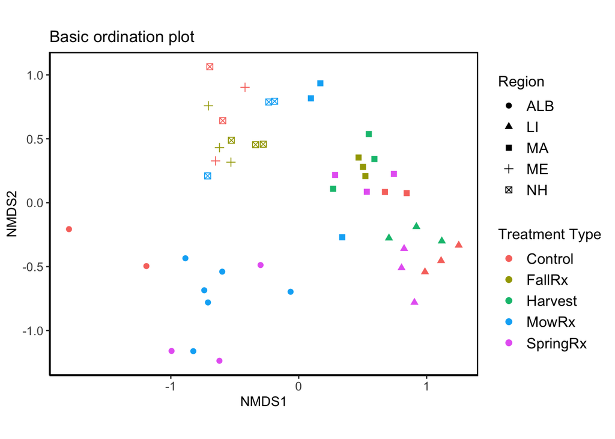

```r
veg.envr <-  envfit(test_2d, meta.data_veg)
veg.spc.envr <- envfit(test_2d, rel_veg5)

site.scores <- as.data.frame(scores(test_2d, display = "sites")) #save NMDS results into dataframe
site.scores <- cbind(site.scores, Treat_Type = meta.data_veg$Treat_Type) #add grouping variable treat type to dataframe
site.scores <- cbind(site.scores, Region = meta.data_veg$Region)
#site.scrs <- cbind(site.scrs, Site = rownames(site.scrs)) #add site names as variable if you want to display on plot


# now for species -------------------
spp.scrs <- as.data.frame(scores(veg.spc.envr, display = "vectors")) #save species intrinsic values into dataframe
spp.scrs <- cbind(spp.scrs, Species = rownames(spp.scrs)) #add species names to dataframe
spp.scrs <- cbind(spp.scrs, pval = veg.spc.envr$vectors$pvals) #add pvalues to dataframe so you can select species which are significant

sig.spp.scrs <- subset(spp.scrs, pval<=0.003) #subset data to show species significant at 0.05


# now for envr data -------------------
env.scores.veg <- as.data.frame(scores(veg.envr, display = "vectors")) #extracts relevant scores from envifit
env.scores.veg <- cbind(env.scores.veg, env.variables = rownames(env.scores.veg)) #and then gives them their names

env.scores.veg <- cbind(env.scores.veg, pval = veg.envr$vectors$pvals) # add pvalues to dataframe
sig.env.scrs <- subset(env.scores.veg, pval<=0.05) #subset data to show variables significant at 0.05


# now begin plotting   -------------------
nmds.plot.vegall <- ggplot(site.scores, aes(x=NMDS1, y=NMDS2))+ #sets up the plot
  geom_point(aes(NMDS1, NMDS2, colour = factor(site.scores$Treat_Type), shape = factor(site.scores$Region)), size = 2)+ #adds site points to plot, shape determined by Landuse, colour determined by Management
  coord_fixed()+
  theme_classic()+
  theme(panel.background = element_rect(fill = NA, colour = "black", size = 1, linetype = "solid"))+
  labs(colour = "Treatment Type", shape = "Region")+ # add legend labels for Management and Landuse
  theme(legend.position = "right", legend.text = element_text(size = 12), legend.title = element_text(size = 12), axis.text = element_text(size = 10)) # add legend at right of plot
nmds.plot.vegall + labs(title = "Basic ordination plot") #displays plot
```

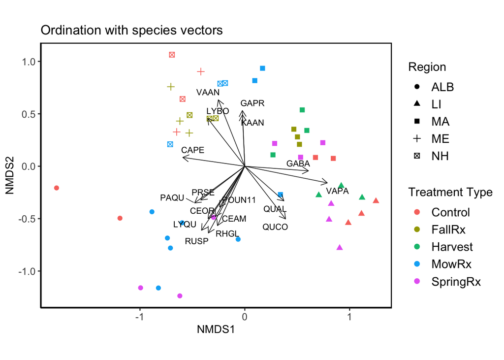

```r
nmds.plot.vegall+
  geom_segment(data = sig.spp.scrs, aes(x = 0, xend=NMDS1, y=0, yend=NMDS2), arrow = arrow(length = unit(0.25, "cm")), colour = "grey10", lwd=0.3) + #add vector arrows of significant species
  ggrepel::geom_text_repel(data = sig.spp.scrs, aes(x=NMDS1, y=NMDS2, label = Species), cex = 3, direction = "both", segment.size = 0.25)+ #add labels for species, use ggrepel::geom_text_repel so that labels do not overlap
  labs(title = "Ordination with species vectors")
```

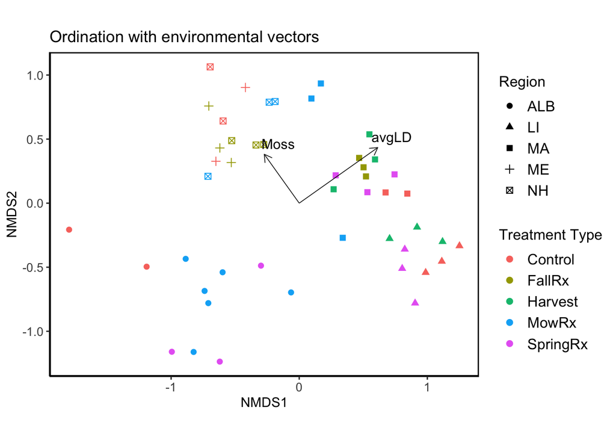

```r
#maybe I should set a lower p value than 0.5? Set to 0.005, still too many - we'll also look per region-group analysis

nmds.plot.vegall+
  geom_segment(data = sig.env.scrs, aes(x = 0, xend=NMDS1, y=0, yend=NMDS2), arrow = arrow(length = unit(0.25, "cm")), colour = "grey10", lwd=0.3) + #add vector arrows of significant env variables
  ggrepel::geom_text_repel(data = sig.env.scrs, aes(x=NMDS1, y=NMDS2, label = env.variables), cex = 4, direction = "both", segment.size = 0.25)+ #add labels for env variables
  labs(title="Ordination with environmental vectors")
```

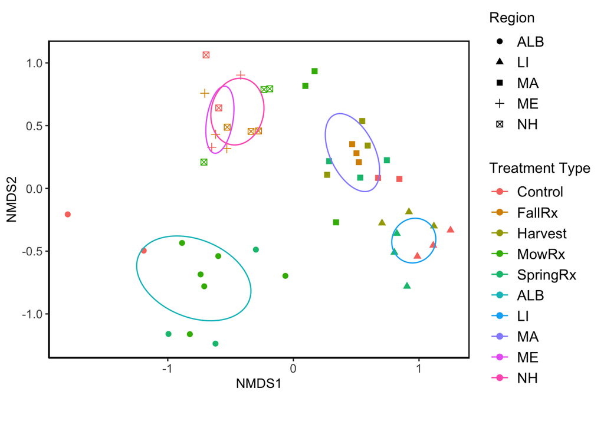

```r
# checking out ellipses -------------------

# function for ellipsess

veganCovEllipse <- function (cov, center = c(0, 0), scale = 1, npoints = 100)
{
  theta <- (0:npoints) * 2 * pi/npoints
  Circle <- cbind(cos(theta), sin(theta))
  t(center + scale * t(Circle %*% chol(cov)))
}

#data for ellipse, in this case using the management factor
df_ell.region <- data.frame() #sets up a data frame before running the function.
 site.scores$Region <- as.factor(site.scores$Region)

for(i in levels(site.scores$Region)){
  df_ell.region <- rbind(df_ell.region, cbind(as.data.frame(with(site.scores [site.scores$Region==i,],
                                                         veganCovEllipse(cov.wt(cbind(NMDS1,NMDS2),wt=rep(1/length(NMDS1),length(NMDS1)))$cov,center=c(mean(NMDS1),mean(NMDS2))))) ,Region=i))
}



# data for labelling the ellipse
NMDS.mean.veg=aggregate(site.scores[ ,c("NMDS1", "NMDS2")],
                         list(group = site.scores$Region), "mean")

# data for labelling the ellipse
NMDS.mean=aggregate(site.scores[,c("NMDS1", "NMDS2")],
                    list(group = site.scores$Region), "mean")

nmds.plot.vegall+
geom_path(data = df_ell.region, aes(x = NMDS1, y = NMDS2, color = Region)) #this is the ellipse, seperate ones by Site.
```

### Plot outcome in ordiplot for quick visual

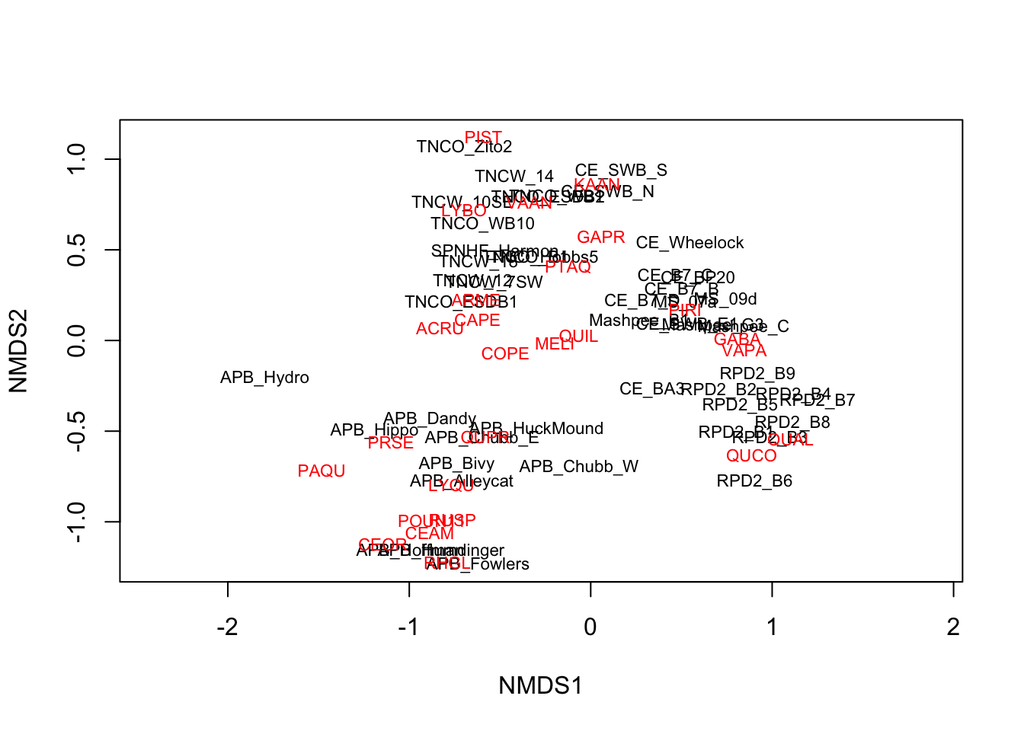

```r
ordiplot(test_2d, type = "t")
```

```r
# looks like region is the reason behind grouping
```

### Going fancier with ggplot

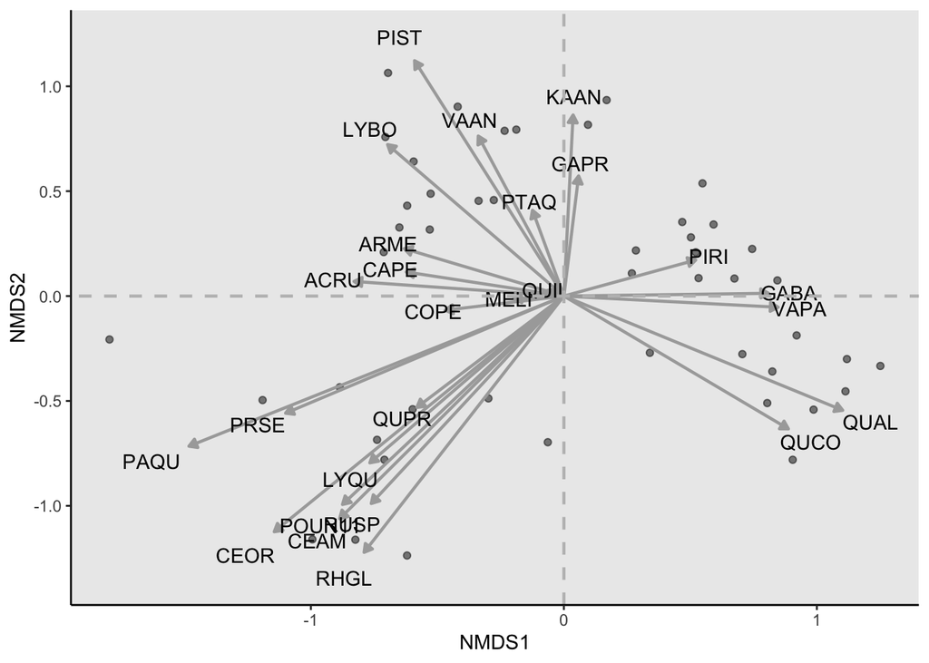

```r
#plot
fort<- fortify(test_2d)
ggplot() +
  geom_point(data = subset(fort, score =='sites'),
             mapping = aes(x = NMDS1, y = NMDS2),
             colour="black",
             alpha=0.5)+
  geom_segment(data = subset(fort, score == 'species'),
               mapping = aes(x = 0, y = 0, xend = NMDS1, yend = NMDS2),
               arrow = arrow(length = unit(0.015, "npc"),
                             type="closed"),
               colour="darkgray",
               linewidth =0.8)+
  geom_text(data = subset(fort, score =='species'),
            mapping = aes(label=label, x=NMDS1*1.1, y=NMDS2*1.1))+
  geom_abline(intercept = 0,slope = 0,linetype="dashed", linewidth=0.8,colour="gray")+
  geom_vline(aes(xintercept=0), linetype="dashed", linewidth=0.8, colour="gray")+
  theme(panel.grid.major = element_blank(),
        panel.grid.minor = element_blank(),
        axis.line = element_line(colour = "black"))
```

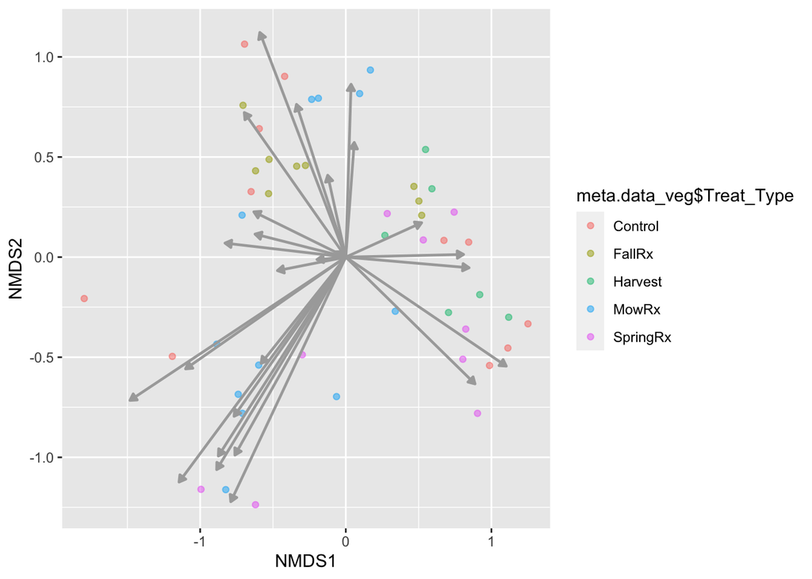

```r
ggplot() +
  geom_point(data = subset(fort, score =='sites'),
             mapping = aes(x = NMDS1, y = NMDS2, color = meta.data_veg$Treat_Type),
             alpha=0.5)+
  geom_segment(data = subset(fort, score == 'species'),
               mapping = aes(x = 0, y = 0, xend = NMDS1, yend = NMDS2),
               arrow = arrow(length = unit(0.015, "npc"),
                             type="closed"),
               colour="darkgray",
               linewidth =0.8)
```

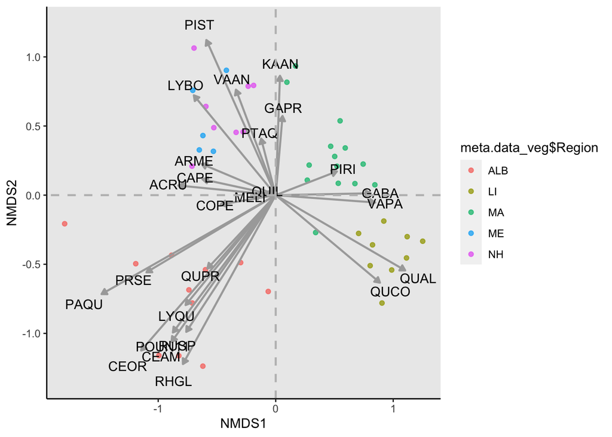

```r
ggplot() +
  geom_point(data = subset(fort, score =='sites'),
             mapping = aes(x = NMDS1, y = NMDS2, color = meta.data_veg$Region),
             alpha=0.75)+
  geom_segment(data = subset(fort, score == 'species'),
               mapping = aes(x = 0, y = 0, xend = NMDS1, yend = NMDS2),
               arrow = arrow(length = unit(0.015, "npc"),
                             type="closed"),
               colour="darkgray",
               linewidth =0.8)+
  geom_text(data = subset(fort, score =='species'),
            mapping = aes(label=label, x=NMDS1*1.1, y=NMDS2*1.1))+
  geom_abline(intercept = 0,slope = 0,linetype="dashed", linewidth=0.8,colour="gray")+
  geom_vline(aes(xintercept=0), linetype="dashed", linewidth=0.8, colour="gray")+
  theme(panel.grid.major = element_blank(),
        panel.grid.minor = element_blank(),
        axis.line = element_line(colour = "black"))
```

```r
# region seems a pretty clear driver of understory composition. Can still run adonis tests etc on other values (permanova for treat or/and region)
```

### Run PerMANOVA to look at the impacts of region and treatment on community composition

```r
# to run PerMANOVA, there is an assumption of evenness across envr factor, therefore check

summary(meta.data_veg)
```

```
##      Site              Region           Treat_Type        Time_from_Treat
##  Length:47          Length:47          Length:47          Min.   : 1.00
##  Class :character   Class :character   Class :character   1st Qu.: 3.00
##  Mode  :character   Mode  :character   Mode  :character   Median : 5.00
##                                                           Mean   :10.81
##                                                           3rd Qu.: 8.00
##                                                           Max.   :33.00
##      Lichen             Moss              Rock          Mineral_Soil
##  Min.   :0.00000   Min.   :0.00000   Min.   :0.00000   Min.   :0.0000
##  1st Qu.:0.00000   1st Qu.:0.04546   1st Qu.:0.00000   1st Qu.:0.0000
##  Median :0.00000   Median :0.31818   Median :0.00000   Median :0.0500
##  Mean   :0.22539   Mean   :0.64955   Mean   :0.02379   Mean   :0.7155
##  3rd Qu.:0.04546   3rd Qu.:0.43561   3rd Qu.:0.00000   3rd Qu.:0.5000
##  Max.   :7.95833   Max.   :8.12500   Max.   :0.80000   Max.   :7.4545
##       Wood         Litter_Duff        avgLD            BA_HA
##  Min.   : 0.000   Min.   :74.09   Min.   :0.8125   Min.   : 1.455
##  1st Qu.: 1.672   1st Qu.:88.28   1st Qu.:2.9811   1st Qu.: 9.409
##  Median : 2.550   Median :90.50   Median :3.7727   Median :15.364
##  Mean   : 3.079   Mean   :88.79   Mean   :4.2491   Mean   :16.673
##  3rd Qu.: 3.614   3rd Qu.:90.50   3rd Qu.:5.4472   3rd Qu.:23.140
##  Max.   :12.000   Max.   :90.50   Max.   :7.8889   Max.   :37.400
##    PIRI.BA_HA
##  Min.   : 1.091
##  1st Qu.: 6.948
##  Median :13.400
##  Mean   :12.856
##  3rd Qu.:16.522
##  Max.   :29.364
```

```r
summary(as.factor(meta.data_veg$Treat_Type))
```

```
##  Control   FallRx  Harvest    MowRx SpringRx
##       11        9        6       12        9
```

```r
# 6 (harvest) - 12 (mowrx): 6, 9, 9, 11, 12

summary(as.factor(meta.data_veg$Region))
```

```
## ALB  LI  MA  ME  NH
##  11   9  14   5   8
```

```r
# 5 (ME) - 14 (MA): 5, 8, 9, 11, 14
```

### PerMANOVA by region

```r
per.region <- adonis2(rel_veg5 ~ Region, data = meta.data_veg)

print(per.region)
```

```
## Permutation test for adonis under reduced model
## Terms added sequentially (first to last)
## Permutation: free
## Number of permutations: 999
##
## adonis2(formula = rel_veg5 ~ Region, data = meta.data_veg)
##          Df SumOfSqs      R2     F Pr(>F)
## Region    4   7.1050 0.47816 9.621  0.001 ***
## Residual 42   7.7542 0.52184
## Total    46  14.8592 1.00000
## ---
## Signif. codes:  0 '***' 0.001 '**' 0.01 '*' 0.05 '.' 0.1 ' ' 1
```

### PerMANOVA by treatment type

```r
per.tt <- adonis2(rel_veg5 ~ Treat_Type, data = meta.data_veg)

print(per.tt)
```

```
## Permutation test for adonis under reduced model
## Terms added sequentially (first to last)
## Permutation: free
## Number of permutations: 999
##
## adonis2(formula = rel_veg5 ~ Treat_Type, data = meta.data_veg)
##            Df SumOfSqs      R2      F Pr(>F)
## Treat_Type  4    2.831 0.19052 2.4713  0.001 ***
## Residual   42   12.028 0.80948
## Total      46   14.859 1.00000
## ---
## Signif. codes:  0 '***' 0.001 '**' 0.01 '*' 0.05 '.' 0.1 ' ' 1
```